# Coral Growth — Size-Dependent Growth Rate Analysis

GLMM analysis of proportional growth rates by taxa, site, habitat, and bleaching period

# Overview

This document models **size-dependent proportional growth rates** for three coral taxa (*Acropora*, *Pocillopora*, *Porites*) using generalized linear mixed models (GLMMs) fitted with `glmmTMB`.

Two research questions are addressed:

1. **Model 1 (Habitat):** Does size-dependent growth rate differ between forereef and backreef habitats around the island before and after the 2019 bleaching event?
2. **Model 2 (Site × Habitat):** Does size-dependent growth rate differ across all site-habitat combinations (LTER1 backreef, LTER1 forereef, LTER2 backreef, LTER2 forereef, etc.) before and after the 2019 bleaching event, island-wide?

**Reference group for all models:** backreef (Model 1) or LTER1 backreef (Model 2), before bleaching.

All models use `log(size_t1)` as the response variable, with `log(size_t0)` as a covariate. The coefficient on `log_size_t0` captures the size-dependence of growth.

# Setup

```r
library(tidyverse)
library(glmmTMB)
library(performance)
library(DHARMa)
library(emmeans)
library(dplyr)
library(purrr)
library(gt)
```

# Data Preparation

## Load & Clean

```r
coral_demography_analysis_data <- read_csv(here::here("..", "eds-coral-data-storage-management", "analysisdata", "coral_demography_analysis_data.csv"), guess_max = 10000) # Correct column type
```

## Filter & Model Preparation

```r
# Exclusion criteria:
# - Millepora excluded (insufficient sample size)
# - Require both size measurements (t0 and t1 non-missing)
# - Only consecutive year pairs (year_t1 - year == 1)
# - Remove zero/negative volumes (measurement errors)
growth_data <- coral_demography_analysis_data %>%
  mutate(year_t1 = year + 1) %>%
  filter(
    taxa != "Mil",
    !is.na(size_t0),
    !is.na(size_t1),
    !is.na(year_t1),
    year_t1 - year == 1,  # consecutive years only
    size_t0 > 0, size_t1 > 0) %>%
  mutate(
    # Set reference levels
    taxa        = relevel(factor(taxa),    ref = "Acr"),
    habitat     = relevel(factor(habitat), ref = "BR"),
    site        = relevel(factor(site),    ref = "LTER1"),
    period = factor(period),
    # Log-transform size variables
    log10_size_t0 = log10(size_t0),
    log10_size_t1 = log10(size_t1)
  )

# Split by taxa for separate models
growth_acr <- growth_data %>% filter(taxa == "Acr")
growth_poc <- growth_data %>% filter(taxa == "Poc")
growth_por <- growth_data %>% filter(taxa == "Por")
```

# Model 1: Habitat-Level Growth Before/After Bleaching

**Question:** Does size-dependent growth rate differ between forereef and backreef habitats before and after the 2019 bleaching event?

**Fixed effects:** `log_size_t0 * habitat * period`

**Reference group:** Backreef, before bleaching.

## Fit Models

```r
m1_acr <- glmmTMB(
  log10_size_t1 ~ log10_size_t0 * habitat * period +
    (1 | transect_id/coral_id) + (1 | year),
  family = gaussian(),
  data   = growth_acr
)
m1_poc <- glmmTMB(
  log10_size_t1 ~ log10_size_t0 * habitat * period +
    (1 | transect_id/coral_id) + (1 | year),
  family = gaussian(),
  data   = growth_poc
)

m1_por <- glmmTMB(
  log10_size_t1 ~ log10_size_t0 * habitat * period +
    (1 | transect_id/coral_id) + (1 | year),
  family = gaussian(),
  data   = growth_por
)
```

## Model Summaries

```r
summary(m1_acr)
```

```
 Family: gaussian  ( identity )
Formula:
log10_size_t1 ~ log10_size_t0 * habitat * period + (1 | transect_id/coral_id) +
    (1 | year)
Data: growth_acr

      AIC       BIC    logLik -2*log(L)  df.resid
   1260.3    1319.3    -618.1    1236.3       998

Random effects:

Conditional model:
 Groups               Name        Variance Std.Dev.
 coral_id:transect_id (Intercept) 0.022550 0.15017
 transect_id          (Intercept) 0.007417 0.08612
 year                 (Intercept) 0.001920 0.04382
 Residual                         0.173727 0.41681
Number of obs: 1010, groups:
coral_id:transect_id, 479; transect_id, 34; year, 11

Dispersion estimate for gaussian family (sigma^2): 0.174

Conditional model:
                                Estimate Std. Error z value Pr(>|z|)
(Intercept)                      0.96768    0.15211   6.362    2e-10 ***
log10_size_t0                    0.70562    0.06003  11.755   <2e-16 ***
habitatOR                        0.36653    0.16017   2.288   0.0221 *
period1                          0.14205    0.17027   0.834   0.4042
log10_size_t0:habitatOR         -0.08443    0.06289  -1.343   0.1794
log10_size_t0:period1           -0.05447    0.06482  -0.840   0.4008
habitatOR:period1               -0.12155    0.19704  -0.617   0.5373
log10_size_t0:habitatOR:period1 -0.06416    0.07630  -0.841   0.4004
---
Signif. codes:  0 '***' 0.001 '**' 0.01 '*' 0.05 '.' 0.1 ' ' 1
```

```r
summary(m1_poc)
```

```
 Family: gaussian  ( identity )
Formula:
log10_size_t1 ~ log10_size_t0 * habitat * period + (1 | transect_id/coral_id) +
    (1 | year)
Data: growth_poc

      AIC       BIC    logLik -2*log(L)  df.resid
   3636.5    3706.5   -1806.3    3612.5      2503

Random effects:

Conditional model:
 Groups               Name        Variance  Std.Dev.
 coral_id:transect_id (Intercept) 2.128e-02 1.459e-01
 transect_id          (Intercept) 2.775e-02 1.666e-01
 year                 (Intercept) 2.052e-10 1.432e-05
 Residual                         2.209e-01 4.700e-01
Number of obs: 2515, groups:
coral_id:transect_id, 1005; transect_id, 35; year, 12

Dispersion estimate for gaussian family (sigma^2): 0.221

Conditional model:
                                 Estimate Std. Error z value Pr(>|z|)
(Intercept)                      1.013912   0.061239  16.557  < 2e-16 ***
log10_size_t0                    0.652122   0.024364  26.765  < 2e-16 ***
habitatOR                        0.043684   0.078441   0.557  0.57760
period1                          0.180643   0.066283   2.725  0.00642 **
log10_size_t0:habitatOR          0.047634   0.026723   1.783  0.07466 .
log10_size_t0:period1           -0.049759   0.029522  -1.685  0.09190 .
habitatOR:period1               -0.230816   0.118721  -1.944  0.05187 .
log10_size_t0:habitatOR:period1  0.009976   0.044295   0.225  0.82182
---
Signif. codes:  0 '***' 0.001 '**' 0.01 '*' 0.05 '.' 0.1 ' ' 1
```

```r
summary(m1_por)
```

```
 Family: gaussian  ( identity )
Formula:
log10_size_t1 ~ log10_size_t0 * habitat * period + (1 | transect_id/coral_id) +
    (1 | year)
Data: growth_por

      AIC       BIC    logLik -2*log(L)  df.resid
  10006.3   10085.4   -4991.2    9982.3      5345

Random effects:

Conditional model:
 Groups               Name        Variance  Std.Dev.
 coral_id:transect_id (Intercept) 5.017e-09 7.083e-05
 transect_id          (Intercept) 1.293e-02 1.137e-01
 year                 (Intercept) 6.859e-03 8.282e-02
 Residual                         3.724e-01 6.103e-01
Number of obs: 5357, groups:
coral_id:transect_id, 1912; transect_id, 35; year, 12

Dispersion estimate for gaussian family (sigma^2): 0.372

Conditional model:
                                 Estimate Std. Error z value Pr(>|z|)
(Intercept)                      0.499837   0.048637   10.28  < 2e-16 ***
log10_size_t0                    0.784799   0.009398   83.50  < 2e-16 ***
habitatOR                        0.400638   0.073272    5.47 4.56e-08 ***
period1                          0.239713   0.063520    3.77 0.000161 ***
log10_size_t0:habitatOR         -0.167219   0.034771   -4.81 1.52e-06 ***
log10_size_t0:period1           -0.047747   0.016314   -2.93 0.003425 **
habitatOR:period1               -0.239599   0.148671   -1.61 0.107048
log10_size_t0:habitatOR:period1  0.048216   0.064875    0.74 0.457356
---
Signif. codes:  0 '***' 0.001 '**' 0.01 '*' 0.05 '.' 0.1 ' ' 1
```

## Model 1 Growth Rates

```r
# Acropora
emtrends(m1_acr, ~ habitat * period, var = "log10_size_t0")
```

```
 habitat period log10_size_t0.trend     SE  df asymp.LCL asymp.UCL
 BR      0                    0.706 0.0600 Inf     0.588     0.823
 OR      0                    0.621 0.0238 Inf     0.575     0.668
 BR      1                    0.651 0.0407 Inf     0.571     0.731
 OR      1                    0.503 0.0343 Inf     0.435     0.570

Confidence level used: 0.95
```

```r
contrast(emtrends(m1_acr, ~ habitat * period, var = "log10_size_t0"),
         method = "pairwise", by = "habitat")
```

```
habitat = BR:
 contrast          estimate     SE  df z.ratio p.value
 period0 - period1   0.0545 0.0648 Inf   0.840  0.4008

habitat = OR:
 contrast          estimate     SE  df z.ratio p.value
 period0 - period1   0.1186 0.0396 Inf   2.996  0.0027
```

```r
# Pocillopora
emtrends(m1_poc, ~ habitat * period, var = "log10_size_t0")
```

```
 habitat period log10_size_t0.trend     SE  df asymp.LCL asymp.UCL
 BR      0                    0.652 0.0244 Inf     0.604     0.700
 OR      0                    0.700 0.0127 Inf     0.675     0.725
 BR      1                    0.602 0.0223 Inf     0.559     0.646
 OR      1                    0.660 0.0313 Inf     0.599     0.721

Confidence level used: 0.95
```

```r
contrast(emtrends(m1_poc, ~ habitat * period, var = "log10_size_t0"),
         method = "pairwise", by = "habitat")
```

```
habitat = BR:
 contrast          estimate     SE  df z.ratio p.value
 period0 - period1   0.0498 0.0295 Inf   1.685  0.0919

habitat = OR:
 contrast          estimate     SE  df z.ratio p.value
 period0 - period1   0.0398 0.0331 Inf   1.202  0.2293
```

```r
# Porites
emtrends(m1_por, ~ habitat * period, var = "log10_size_t0")
```

```
 habitat period log10_size_t0.trend     SE  df asymp.LCL asymp.UCL
 BR      0                    0.785 0.0094 Inf     0.766     0.803
 OR      0                    0.618 0.0336 Inf     0.552     0.683
 BR      1                    0.737 0.0135 Inf     0.711     0.763
 OR      1                    0.618 0.0532 Inf     0.514     0.722

Confidence level used: 0.95
```

```r
contrast(emtrends(m1_por, ~ habitat * period, var = "log10_size_t0"),
         method = "pairwise", by = "habitat")
```

```
habitat = BR:
 contrast           estimate     SE  df z.ratio p.value
 period0 - period1  0.047747 0.0163 Inf   2.927  0.0034

habitat = OR:
 contrast           estimate     SE  df z.ratio p.value
 period0 - period1 -0.000468 0.0629 Inf  -0.007  0.9941
```

```r
models <- list(ACR = m1_acr, POC = m1_poc, POR = m1_por)

# Group-specific slopes
slopes <- imap_dfr(models, ~ as.data.frame(
  emtrends(.x, ~ habitat * period, var = "log10_size_t0")
) |> mutate(taxon = .y))

# Within-habitat period contrasts
contrasts <- imap_dfr(models, ~ as.data.frame(
  pairs(emtrends(.x, ~ period | habitat, var = "log10_size_t0"))
) |> mutate(taxon = .y))

# Clean table
contrasts |>
  select(taxon, habitat, contrast, estimate, SE, z.ratio, p.value) |>
  mutate(
    across(c(estimate, SE, z.ratio), \(x) round(x, 3)),
    sig = case_when(
      p.value < 0.001 ~ "***",
      p.value < 0.01  ~ "**",
      p.value < 0.05  ~ "*",
      TRUE ~ ""
    ),
    p.value = format.pval(p.value, digits = 2, eps = 0.001)
  ) |>
  arrange(taxon, habitat) |>
  gt(groupname_col = "taxon") |>
  cols_label(
    habitat = "Habitat",
    contrast = "Contrast",
    estimate = "Δ slope",
    z.ratio = "z",
    p.value = "p",
    sig = ""
  ) |>
  tab_header(title = "Change in size-dependent growth slope after 2019 bleaching")
```

Change in size-dependent growth slope after 2019 bleaching

| Habitat | Contrast | Δ slope | SE | z | p |  |
| --- | --- | --- | --- | --- | --- | --- |
| ACR |  |  |  |  |  |  |
| BR | period0 - period1 | 0.054 | 0.065 | 0.840 | 0.4008 |  |
| OR | period0 - period1 | 0.119 | 0.040 | 2.996 | 0.0027 | ** |
| POC |  |  |  |  |  |  |
| BR | period0 - period1 | 0.050 | 0.030 | 1.685 | 0.0919 |  |
| OR | period0 - period1 | 0.040 | 0.033 | 1.202 | 0.2293 |  |
| POR |  |  |  |  |  |  |
| BR | period0 - period1 | 0.048 | 0.016 | 2.927 | 0.0034 | ** |
| OR | period0 - period1 | 0.000 | 0.063 | -0.007 | 0.9941 |  |

```r
# M1 prediction grids — population-level, no random effects

# Build a prediction grid: every habitat × period combination paired with
# 100 evenly-spaced log10_size_t0 values spanning the observed range.
acr_pred_grid_m1 <- growth_acr %>%
  distinct(habitat, period) %>%  # unique habitat × period combos (4 rows: BR/OR × 0/1)
  crossing(log10_size_t0 = seq(min(growth_acr$log10_size_t0), # full crossing : 4 × 100 = 400 rows
                               max(growth_acr$log10_size_t0),
                               length.out = 100))

acr_pred_grid_m1$pred_log10_t1 <- predict(m1_acr, newdata = acr_pred_grid_m1,
                                          type = "response", re.form = NA)
poc_pred_grid_m1 <- growth_poc %>%
  distinct(habitat, period) %>%
  crossing(log10_size_t0 = seq(min(growth_poc$log10_size_t0),
                               max(growth_poc$log10_size_t0),
                               length.out = 100))
poc_pred_grid_m1$pred_log10_t1 <- predict(m1_poc, newdata = poc_pred_grid_m1,
                                           type = "response", re.form = NA)

por_pred_grid_m1 <- growth_por %>%
  distinct(habitat, period) %>%
  crossing(log10_size_t0 = seq(min(growth_por$log10_size_t0),
                               max(growth_por$log10_size_t0),
                               length.out = 100))
por_pred_grid_m1$pred_log10_t1 <- predict(m1_por, newdata = por_pred_grid_m1,
                                           type = "response", re.form = NA)
```

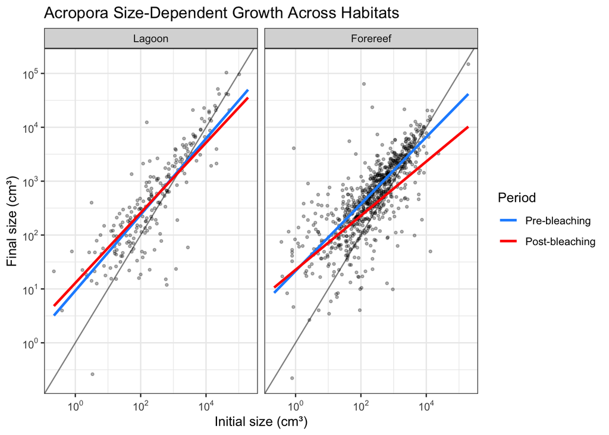

```r
ggplot() +
  geom_point(data = growth_acr,
             aes(x = log10_size_t0, y = log10_size_t1), alpha = 0.3, size = 0.8) +
  geom_abline(slope = 1, intercept = 0, alpha = 0.5) +
  geom_line(data = acr_pred_grid_m1,
            aes(x = log10_size_t0, y = pred_log10_t1, color = period), linewidth = 1) +
  facet_grid(~ habitat, labeller = labeller(habitat = c("BR" = "Lagoon", "OR" = "Forereef"))) +
  scale_color_manual(values = c("0" = "dodgerblue", "1" = "red"),
                     labels = c("0" = "Pre-bleaching", "1" = "Post-bleaching")) +
  scale_x_continuous(labels = scales::label_math(10^.x)) +
  scale_y_continuous(labels = scales::label_math(10^.x)) +
  theme_bw() +
  labs(title = "Acropora Size-Dependent Growth Across Habitats", x = "Initial size (cm³)", y = "Final size (cm³)", color = "Period")
```

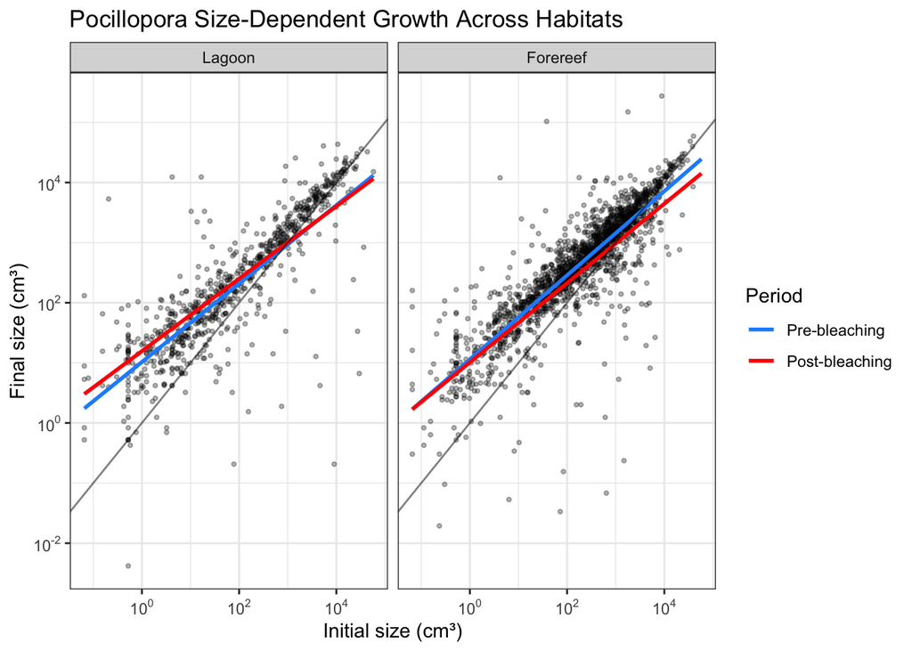

```r
ggsave(here::here("growth", "figs", "acr_growth_hab_plot.png"), height = 5, width = 10)

ggplot() +
  geom_point(data = growth_poc,
             aes(x = log10_size_t0, y = log10_size_t1), alpha = 0.3, size = 0.8) +
  geom_line(data = poc_pred_grid_m1,
            aes(x = log10_size_t0, y = pred_log10_t1, color = period), linewidth = 1) +
  geom_abline(slope = 1, intercept = 0, alpha = 0.5) +
  facet_grid(~ habitat, labeller = labeller(habitat = c("BR" = "Lagoon", "OR" = "Forereef"))) +
  scale_color_manual(values = c("0" = "dodgerblue", "1" = "red"),
                     labels = c("0" = "Pre-bleaching", "1" = "Post-bleaching")) +
  scale_x_continuous(labels = scales::label_math(10^.x)) +
  scale_y_continuous(labels = scales::label_math(10^.x)) +
  theme_bw() +
  labs(title = "Pocillopora Size-Dependent Growth Across Habitats", x = "Initial size (cm³)", y = "Final size (cm³)", color = "Period")
```

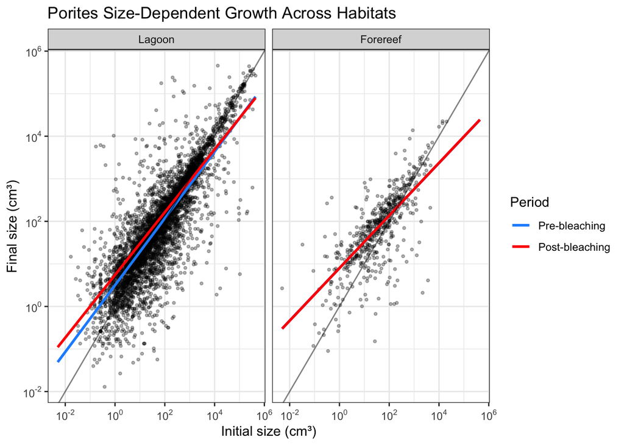

```r
ggsave(here::here("growth", "figs", "poc_growth_hab_plot.png"), height = 5, width = 10)

ggplot() +
  geom_point(data = growth_por,
             aes(x = log10_size_t0, y = log10_size_t1), alpha = 0.3, size = 0.8) +
  geom_line(data = por_pred_grid_m1,
            aes(x = log10_size_t0, y = pred_log10_t1, color = period), linewidth = 1) +
  geom_abline(slope = 1, intercept = 0, alpha = 0.5) +
  facet_grid(~ habitat, labeller = labeller(habitat = c("BR" = "Lagoon", "OR" = "Forereef"))) +
  scale_color_manual(values = c("0" = "dodgerblue", "1" = "red"),
                     labels = c("0" = "Pre-bleaching", "1" = "Post-bleaching")) +
  scale_x_continuous(labels = scales::label_math(10^.x)) +
  scale_y_continuous(labels = scales::label_math(10^.x)) +
  theme_bw() +
  labs(title = "Porites Size-Dependent Growth Across Habitats", x = "Initial size (cm³)", y = "Final size (cm³)", color = "Period")
```

```r
ggsave(here::here("growth", "figs", "por_growth_hab_plot.png"), height = 5, width = 10)
```

## Model Checks

### *Acropora* residuals

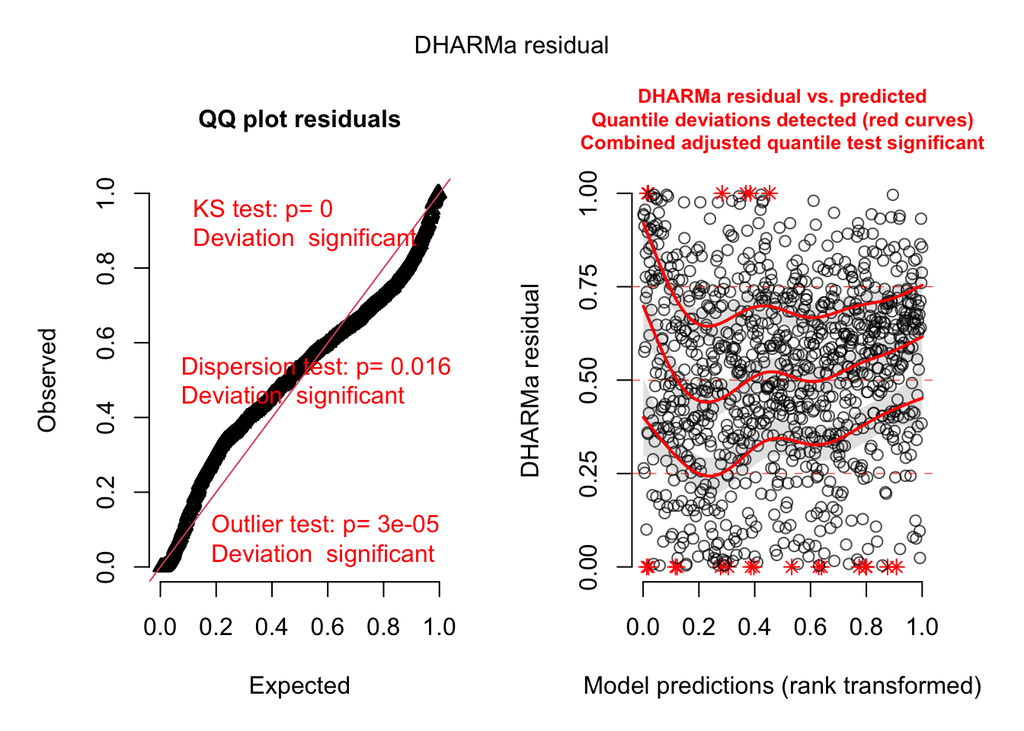

```r
acr_growth_mod_output <- simulateResiduals(fittedModel = m1_acr, plot = FALSE)
plot(acr_growth_mod_output)
```

### *Pocillopora* residuals

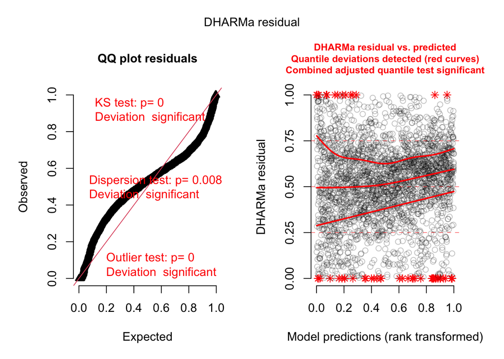

```r
poc_growth_mod_output <- simulateResiduals(fittedModel = m1_poc, plot = FALSE)
plot(poc_growth_mod_output)
```

### *Porites* residuals

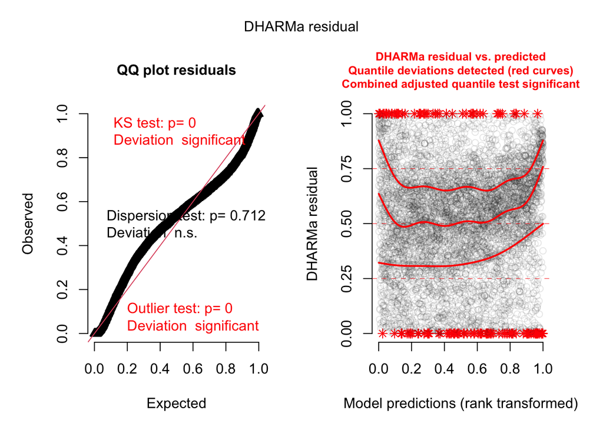

```r
por_growth_mod_output <- simulateResiduals(fittedModel = m1_por, plot = FALSE)
plot(por_growth_mod_output)
```

# Model 2: Island-Wide Growth by Site × Habitat Before/After Bleaching

**Question:** Does size-dependent growth rate differ across all site-habitat combinations (LTER1 backreef, LTER1 forereef, LTER2 backreef, LTER2 forereef, etc.) before and after the 2019 bleaching event, island-wide?

**Fixed effects:** `log_size_t0 * site * habitat * period`

**Random effects:** Colonies nested in transects `(1 | transect_id/coral_id)` + inter-annual variation `(1 | year)`

Note: Site is included as a **fixed effect** here because the question explicitly compares specific named sites. Transect nesting is simplified to `transect_id/coral_id` since site is already captured in the fixed effects and in `transect_id`.

**Reference group:** LTER1 backreef, before bleaching.

## Fit Models

```r
m2_acr <- glmmTMB(
  log10_size_t1 ~ log10_size_t0 * site * habitat * period +
    (1 | transect_id/coral_id) + (1 | year),
  family = gaussian(),
  data   = growth_acr
)

m2_poc <- glmmTMB(
  log10_size_t1 ~ log10_size_t0 * site * habitat * period +
    (1 | transect_id/coral_id) + (1 | year),
  family = gaussian(),
  data   = growth_poc
)

m2_por <- glmmTMB(
  log10_size_t1 ~ log10_size_t0 * site * habitat * period +
    (1 | transect_id/coral_id) + (1 | year),
  family = gaussian(),
  data   = growth_por
)
```

## Model Summaries

```r
summary(m2_acr)
```

```
 Family: gaussian  ( identity )
Formula:
log10_size_t1 ~ log10_size_t0 * site * habitat * period + (1 |
    transect_id/coral_id) + (1 | year)
Data: growth_acr

      AIC       BIC    logLik -2*log(L)  df.resid
   1230.5    1407.5    -579.3    1158.5       974

Random effects:

Conditional model:
 Groups               Name        Variance Std.Dev.
 coral_id:transect_id (Intercept) 0.018987 0.13779
 transect_id          (Intercept) 0.004607 0.06788
 year                 (Intercept) 0.001516 0.03893
 Residual                         0.163374 0.40420
Number of obs: 1010, groups:
coral_id:transect_id, 479; transect_id, 34; year, 11

Dispersion estimate for gaussian family (sigma^2): 0.163

Conditional model:
                                          Estimate Std. Error z value Pr(>|z|)
(Intercept)                                1.05738    0.29274   3.612 0.000304
log10_size_t0                              0.66410    0.11162   5.950 2.69e-09
siteLTER2                                 -0.55311    0.38817  -1.425 0.154177
siteLTER4                                  0.36533    0.37585   0.972 0.331043
siteLTER5                                  0.76650    0.81768   0.937 0.348547
habitatOR                                  0.19857    0.31581   0.629 0.529506
period1                                    0.14491    0.54581   0.266 0.790622
log10_size_t0:siteLTER2                    0.26091    0.14806   1.762 0.078048
log10_size_t0:siteLTER4                   -0.26465    0.15824  -1.672 0.094428
log10_size_t0:siteLTER5                   -0.13453    0.25274  -0.532 0.594534
log10_size_t0:habitatOR                   -0.02217    0.11905  -0.186 0.852286
siteLTER2:habitatOR                        0.51676    0.42724   1.210 0.226457
siteLTER4:habitatOR                       -0.50629    0.41158  -1.230 0.218658
siteLTER5:habitatOR                       -0.40030    0.83206  -0.481 0.630452
log10_size_t0:period1                     -0.03844    0.32991  -0.117 0.907238
siteLTER2:period1                          0.48165    0.68632   0.702 0.482810
```

[output cut: 36 more lines]

```
log10_size_t0:siteLTER2:habitatOR
log10_size_t0:siteLTER4:habitatOR         *
log10_size_t0:siteLTER5:habitatOR
log10_size_t0:siteLTER2:period1
log10_size_t0:siteLTER4:period1
log10_size_t0:siteLTER5:period1
log10_size_t0:habitatOR:period1
siteLTER2:habitatOR:period1
siteLTER4:habitatOR:period1               .
siteLTER5:habitatOR:period1
log10_size_t0:siteLTER2:habitatOR:period1
log10_size_t0:siteLTER4:habitatOR:period1
log10_size_t0:siteLTER5:habitatOR:period1
---
Signif. codes:  0 '***' 0.001 '**' 0.01 '*' 0.05 '.' 0.1 ' ' 1
```

```r
summary(m2_poc)
```

```
 Family: gaussian  ( identity )
Formula:
log10_size_t1 ~ log10_size_t0 * site * habitat * period + (1 |
    transect_id/coral_id) + (1 | year)
Data: growth_poc

      AIC       BIC    logLik -2*log(L)  df.resid
   3606.6    3816.5   -1767.3    3534.6      2479

Random effects:

Conditional model:
 Groups               Name        Variance  Std.Dev.
 coral_id:transect_id (Intercept) 2.393e-02 1.547e-01
 transect_id          (Intercept) 1.791e-02 1.338e-01
 year                 (Intercept) 1.843e-09 4.293e-05
 Residual                         2.126e-01 4.611e-01
Number of obs: 2515, groups:
coral_id:transect_id, 1005; transect_id, 35; year, 12

Dispersion estimate for gaussian family (sigma^2): 0.213

Conditional model:
                                           Estimate Std. Error z value Pr(>|z|)
(Intercept)                                0.862117   0.120710   7.142  9.2e-13
log10_size_t0                              0.694015   0.056715  12.237  < 2e-16
siteLTER2                                  0.211104   0.157615   1.339  0.18045
siteLTER4                                  0.145299   0.155581   0.934  0.35035
siteLTER5                                  0.238163   0.182322   1.306  0.19146
habitatOR                                  0.121898   0.145171   0.840  0.40108
period1                                    0.332564   0.138870   2.395  0.01663
log10_size_t0:siteLTER2                   -0.084009   0.074215  -1.132  0.25765
log10_size_t0:siteLTER4                   -0.085766   0.072845  -1.177  0.23904
log10_size_t0:siteLTER5                   -0.007547   0.071044  -0.106  0.91539
log10_size_t0:habitatOR                    0.033895   0.059184   0.573  0.56684
siteLTER2:habitatOR                       -0.025302   0.198824  -0.127  0.89873
siteLTER4:habitatOR                        0.002740   0.199583   0.014  0.98905
siteLTER5:habitatOR                       -0.179042   0.215356  -0.831  0.40576
log10_size_t0:period1                     -0.258735   0.083330  -3.105  0.00190
siteLTER2:period1                         -0.116925   0.197002  -0.594  0.55283
```

[output cut: 36 more lines]

```
log10_size_t0:siteLTER2:habitatOR
log10_size_t0:siteLTER4:habitatOR
log10_size_t0:siteLTER5:habitatOR
log10_size_t0:siteLTER2:period1           *
log10_size_t0:siteLTER4:period1           .
log10_size_t0:siteLTER5:period1           **
log10_size_t0:habitatOR:period1           *
siteLTER2:habitatOR:period1               ***
siteLTER4:habitatOR:period1               **
siteLTER5:habitatOR:period1               **
log10_size_t0:siteLTER2:habitatOR:period1 **
log10_size_t0:siteLTER4:habitatOR:period1 .
log10_size_t0:siteLTER5:habitatOR:period1 .
---
Signif. codes:  0 '***' 0.001 '**' 0.01 '*' 0.05 '.' 0.1 ' ' 1
```

```r
summary(m2_por)
```

```
 Family: gaussian  ( identity )
Formula:
log10_size_t1 ~ log10_size_t0 * site * habitat * period + (1 |
    transect_id/coral_id) + (1 | year)
Data: growth_por

      AIC       BIC    logLik -2*log(L)  df.resid
  10005.5   10242.6   -4966.8    9933.5      5321

Random effects:

Conditional model:
 Groups               Name        Variance  Std.Dev.
 coral_id:transect_id (Intercept) 2.319e-09 4.816e-05
 transect_id          (Intercept) 1.147e-02 1.071e-01
 year                 (Intercept) 6.549e-03 8.093e-02
 Residual                         3.693e-01 6.077e-01
Number of obs: 5357, groups:
coral_id:transect_id, 1912; transect_id, 35; year, 12

Dispersion estimate for gaussian family (sigma^2): 0.369

Conditional model:
                                           Estimate Std. Error z value Pr(>|z|)
(Intercept)                                0.542721   0.077547    7.00 2.58e-12
log10_size_t0                              0.742170   0.023320   31.83  < 2e-16
siteLTER2                                  0.043899   0.095334    0.46 0.645172
siteLTER4                                 -0.048411   0.095663   -0.51 0.612818
siteLTER5                                 -0.140861   0.096791   -1.46 0.145583
habitatOR                                  0.446307   0.114875    3.89 0.000102
period1                                    0.277904   0.103408    2.69 0.007200
log10_size_t0:siteLTER2                    0.005664   0.030002    0.19 0.850272
log10_size_t0:siteLTER4                    0.046069   0.028864    1.60 0.110477
log10_size_t0:siteLTER5                    0.095245   0.029128    3.27 0.001076
log10_size_t0:habitatOR                   -0.159704   0.051222   -3.12 0.001822
siteLTER2:habitatOR                       -0.148397   0.193185   -0.77 0.442392
siteLTER4:habitatOR                       -0.391766   0.260529   -1.50 0.132650
siteLTER5:habitatOR                       -0.017073   0.189792   -0.09 0.928322
log10_size_t0:period1                     -0.097468   0.043420   -2.24 0.024783
siteLTER2:period1                         -0.010827   0.127297   -0.09 0.932219
```

[output cut: 36 more lines]

```
log10_size_t0:siteLTER2:habitatOR
log10_size_t0:siteLTER4:habitatOR
log10_size_t0:siteLTER5:habitatOR
log10_size_t0:siteLTER2:period1
log10_size_t0:siteLTER4:period1
log10_size_t0:siteLTER5:period1
log10_size_t0:habitatOR:period1
siteLTER2:habitatOR:period1
siteLTER4:habitatOR:period1
siteLTER5:habitatOR:period1
log10_size_t0:siteLTER2:habitatOR:period1
log10_size_t0:siteLTER4:habitatOR:period1
log10_size_t0:siteLTER5:habitatOR:period1
---
Signif. codes:  0 '***' 0.001 '**' 0.01 '*' 0.05 '.' 0.1 ' ' 1
```

## Model 2 Growth Rates

```r
# Acropora
emtrends(m2_acr, ~ site * habitat * period, var = "log10_size_t0")
```

```
 site  habitat period log10_size_t0.trend     SE  df asymp.LCL asymp.UCL
 LTER1 BR      0                    0.664 0.1120 Inf    0.4453     0.883
 LTER2 BR      0                    0.925 0.1000 Inf    0.7289     1.121
 LTER4 BR      0                    0.399 0.1160 Inf    0.1717     0.627
 LTER5 BR      0                    0.530 0.2260 Inf    0.0858     0.973
 LTER1 OR      0                    0.642 0.0491 Inf    0.5457     0.738
 LTER2 OR      0                    0.636 0.0507 Inf    0.5364     0.735
 LTER4 OR      0                    0.721 0.0421 Inf    0.6387     0.804
 LTER5 OR      0                    0.527 0.0381 Inf    0.4523     0.602
 LTER1 BR      1                    0.626 0.3080 Inf    0.0225     1.229
 LTER2 BR      1                    0.628 0.1100 Inf    0.4112     0.844
 LTER4 BR      1                    0.570 0.0566 Inf    0.4592     0.681
 LTER5 BR      1                    0.656 0.1030 Inf    0.4537     0.858
 LTER1 OR      1                    0.772 0.1380 Inf    0.5008     1.043
 LTER2 OR      1                    0.614 0.0630 Inf    0.4907     0.738
 LTER4 OR      1                    0.481 0.0468 Inf    0.3891     0.572
 LTER5 OR      1                    0.326 0.0619 Inf    0.2049     0.448

Confidence level used: 0.95
```

```r
# Pocillopora
emtrends(m2_poc, ~ site * habitat * period, var = "log10_size_t0")
```

```
 site  habitat period log10_size_t0.trend     SE  df asymp.LCL asymp.UCL
 LTER1 BR      0                    0.694 0.0567 Inf   0.58285     0.805
 LTER2 BR      0                    0.610 0.0501 Inf   0.51189     0.708
 LTER4 BR      0                    0.608 0.0476 Inf   0.51503     0.701
 LTER5 BR      0                    0.686 0.0433 Inf   0.60158     0.771
 LTER1 OR      0                    0.728 0.0190 Inf   0.69065     0.765
 LTER2 OR      0                    0.654 0.0261 Inf   0.60235     0.705
 LTER4 OR      0                    0.671 0.0347 Inf   0.60327     0.739
 LTER5 OR      0                    0.705 0.0272 Inf   0.65125     0.758
 LTER1 BR      1                    0.435 0.0621 Inf   0.31351     0.557
 LTER2 BR      1                    0.576 0.0454 Inf   0.48683     0.665
 LTER4 BR      1                    0.520 0.0392 Inf   0.44333     0.597
 LTER5 BR      1                    0.718 0.0407 Inf   0.63812     0.798
 LTER1 OR      1                    0.184 0.0966 Inf  -0.00521     0.373
 LTER2 OR      1                    0.761 0.0591 Inf   0.64471     0.877
 LTER4 OR      1                    0.574 0.0669 Inf   0.44316     0.706
 LTER5 OR      1                    0.719 0.0524 Inf   0.61608     0.821

Confidence level used: 0.95
```

```r
# Porites
emtrends(m2_por, ~ site * habitat * period, var = "log10_size_t0")
```

```
 site  habitat period log10_size_t0.trend     SE  df asymp.LCL asymp.UCL
 LTER1 BR      0                    0.742 0.0233 Inf     0.696     0.788
 LTER2 BR      0                    0.748 0.0188 Inf     0.711     0.785
 LTER4 BR      0                    0.788 0.0170 Inf     0.755     0.822
 LTER5 BR      0                    0.837 0.0174 Inf     0.803     0.872
 LTER1 OR      0                    0.582 0.0455 Inf     0.493     0.672
 LTER2 OR      0                    0.557 0.0743 Inf     0.411     0.702
 LTER4 OR      0                    0.848 0.1360 Inf     0.582     1.114
 LTER5 OR      0                    0.717 0.0740 Inf     0.572     0.862
 LTER1 BR      1                    0.645 0.0369 Inf     0.572     0.717
 LTER2 BR      1                    0.712 0.0331 Inf     0.647     0.776
 LTER4 BR      1                    0.728 0.0222 Inf     0.684     0.771
 LTER5 BR      1                    0.784 0.0229 Inf     0.740     0.829
 LTER1 OR      1                    0.262 0.4390 Inf    -0.598     1.122
 LTER2 OR      1                    0.559 0.1100 Inf     0.343     0.775
 LTER4 OR      1                    0.370 0.1410 Inf     0.094     0.646
 LTER5 OR      1                    0.714 0.0691 Inf     0.579     0.850

Confidence level used: 0.95
```

```r
models2 <- list(ACR = m2_acr, POC = m2_poc, POR = m2_por)

# Group-specific slopes (by site × habitat × period)
slopes2 <- imap_dfr(models2, ~ as.data.frame(
  emtrends(.x, ~ site * habitat * period, var = "log10_size_t0")
) |> mutate(taxon = .y))

# Within-habitat period contrasts at each site
contrasts2 <- imap_dfr(models2, ~ as.data.frame(
  pairs(emtrends(.x, ~ period | site * habitat, var = "log10_size_t0"))
) |> mutate(taxon = .y))

# Clean table
contrasts2 |>
  select(taxon, site, habitat, contrast, estimate, SE, z.ratio, p.value) |>
  mutate(
    across(c(estimate, SE, z.ratio), \(x) round(x, 3)),
    sig = case_when(
      p.value < 0.001 ~ "***",
      p.value < 0.01  ~ "**",
      p.value < 0.05  ~ "*",
      TRUE ~ ""
    ),
    p.value = format.pval(p.value, digits = 2, eps = 0.001)
  ) |>
  arrange(taxon, site, habitat) |>
  gt(groupname_col = "taxon") |>
  cols_label(
    site = "Site",
    habitat = "Habitat",
    contrast = "Contrast",
    estimate = "Δ slope",
    z.ratio = "z",
    p.value = "p",
    sig = ""
  ) |>
  tab_header(title = "Change in size-dependent growth slope after 2019 bleaching, by site")
```

Change in size-dependent growth slope after 2019 bleaching, by site

| Site | Habitat | Contrast | Δ slope | SE | z | p |  |
| --- | --- | --- | --- | --- | --- | --- | --- |
| ACR |  |  |  |  |  |  |  |
| LTER1 | BR | period0 - period1 | 0.038 | 0.330 | 0.117 | 0.9072 |  |
| LTER1 | OR | period0 - period1 | -0.130 | 0.146 | -0.888 | 0.3747 |  |
| LTER2 | BR | period0 - period1 | 0.297 | 0.142 | 2.093 | 0.0363 | * |
| LTER2 | OR | period0 - period1 | 0.022 | 0.079 | 0.272 | 0.7855 |  |
| LTER4 | BR | period0 - period1 | -0.171 | 0.127 | -1.343 | 0.1793 |  |
| LTER4 | OR | period0 - period1 | 0.241 | 0.061 | 3.921 | <0.001 | *** |
| LTER5 | BR | period0 - period1 | -0.126 | 0.249 | -0.508 | 0.6112 |  |
| LTER5 | OR | period0 - period1 | 0.201 | 0.072 | 2.795 | 0.0052 | ** |
| POC |  |  |  |  |  |  |  |
| LTER1 | BR | period0 - period1 | 0.259 | 0.083 | 3.105 | 0.0019 | ** |
| LTER1 | OR | period0 - period1 | 0.544 | 0.098 | 5.554 | <0.001 | *** |
| LTER2 | BR | period0 - period1 | 0.034 | 0.065 | 0.524 | 0.6005 |  |
| LTER2 | OR | period0 - period1 | -0.107 | 0.064 | -1.683 | 0.0923 |  |
| LTER4 | BR | period0 - period1 | 0.088 | 0.058 | 1.511 | 0.1308 |  |
| LTER4 | OR | period0 - period1 | 0.097 | 0.075 | 1.297 | 0.1947 |  |
| LTER5 | BR | period0 - period1 | -0.031 | 0.058 | -0.545 | 0.5860 |  |
| LTER5 | OR | period0 - period1 | -0.014 | 0.059 | -0.242 | 0.8087 |  |
| POR |  |  |  |  |  |  |  |
| LTER1 | BR | period0 - period1 | 0.097 | 0.043 | 2.245 | 0.0248 | * |
| LTER1 | OR | period0 - period1 | 0.320 | 0.441 | 0.727 | 0.4674 |  |
| LTER2 | BR | period0 - period1 | 0.036 | 0.038 | 0.965 | 0.3346 |  |
| LTER2 | OR | period0 - period1 | -0.002 | 0.133 | -0.017 | 0.9863 |  |
| LTER4 | BR | period0 - period1 | 0.061 | 0.028 | 2.178 | 0.0294 | * |
| LTER4 | OR | period0 - period1 | 0.478 | 0.196 | 2.437 | 0.0148 | * |
| LTER5 | BR | period0 - period1 | 0.053 | 0.029 | 1.854 | 0.0638 |  |
| LTER5 | OR | period0 - period1 | 0.003 | 0.101 | 0.026 | 0.9790 |  |

```r
acr_pred_grid_m2 <- growth_acr %>%
  distinct(site, habitat, period) %>%
  crossing(log10_size_t0 = seq(min(growth_acr$log10_size_t0),
                               max(growth_acr$log10_size_t0),
                               length.out = 100))
acr_pred_grid_m2$pred_log10_t1 <- predict(m2_acr, newdata = acr_pred_grid_m2,
                                           type = "response", re.form = NA)

poc_pred_grid_m2 <- growth_poc %>%
  distinct(site, habitat, period) %>%
  crossing(log10_size_t0 = seq(min(growth_poc$log10_size_t0),
                               max(growth_poc$log10_size_t0),
                               length.out = 100))
poc_pred_grid_m2$pred_log10_t1 <- predict(m2_poc, newdata = poc_pred_grid_m2,
                                           type = "response", re.form = NA)

por_pred_grid_m2 <- growth_por %>%
  distinct(site, habitat, period) %>%
  crossing(log10_size_t0 = seq(min(growth_por$log10_size_t0),
                               max(growth_por$log10_size_t0),
                               length.out = 100))
por_pred_grid_m2$pred_log10_t1 <- predict(m2_por, newdata = por_pred_grid_m2,
                                           type = "response", re.form = NA)
```

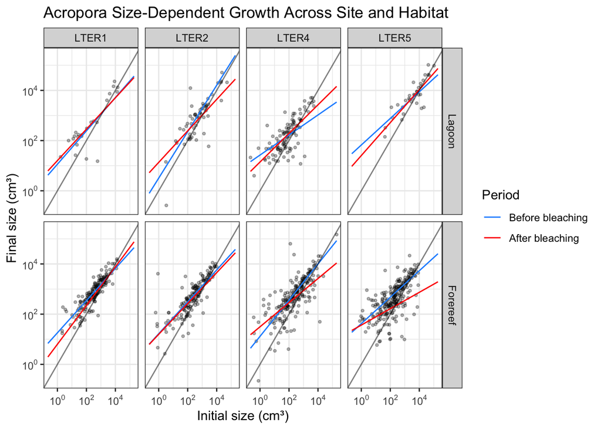

```r
ggplot() +
  geom_point(data = growth_acr,
             aes(x = log10_size_t0, y = log10_size_t1), alpha = 0.3, size = 0.8) +
  geom_line(data = acr_pred_grid_m2,
            aes(x = log10_size_t0, y = pred_log10_t1, color = period)) +
  geom_abline(slope = 1, intercept = 0, alpha = 0.5) +
  scale_color_manual(values = c("0" = "dodgerblue", "1" = "red"),
                     labels = c("0" = "Before bleaching", "1" = "After bleaching")) +
  facet_grid(habitat ~ site, labeller = labeller(habitat = c("BR" = "Lagoon", "OR" = "Forereef"))) +
  labs(x = "Initial size (cm³)",
       y = "Final size (cm³)",
       title = "Acropora Size-Dependent Growth Across Site and Habitat", color = "Period") +
  scale_x_continuous(labels = scales::label_math(10^.x)) +
  scale_y_continuous(labels = scales::label_math(10^.x)) +
  theme_bw()
```

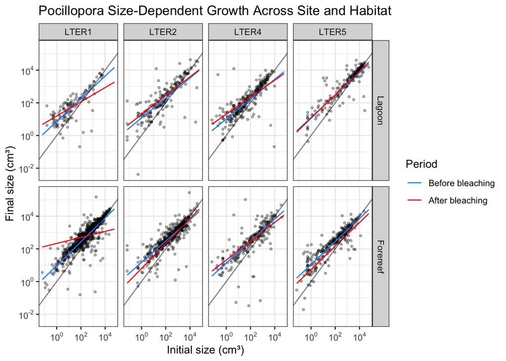

```r
ggsave(here::here("growth", "figs", "acr_site_growth_plot.png"), height = 5, width = 10)

ggplot() +
  geom_point(data = growth_poc,
             aes(x = log10_size_t0, y = log10_size_t1), alpha = 0.3, size = 0.8) +
  geom_line(data = poc_pred_grid_m2,
            aes(x = log10_size_t0, y = pred_log10_t1, color = period)) +
  geom_abline(slope = 1, intercept = 0, alpha = 0.5) +
  scale_color_manual(values = c("0" = "dodgerblue", "1" = "red"),
                     labels = c("0" = "Before bleaching", "1" = "After bleaching")) +
  facet_grid(habitat ~ site, labeller = labeller(habitat = c("BR" = "Lagoon", "OR" = "Forereef"))) +
  labs(x = "Initial size (cm³)",
       y = "Final size (cm³)",
       title = "Pocillopora Size-Dependent Growth Across Site and Habitat", color = "Period") +
  scale_x_continuous(labels = scales::label_math(10^.x)) +
  scale_y_continuous(labels = scales::label_math(10^.x)) +
  theme_bw()
```

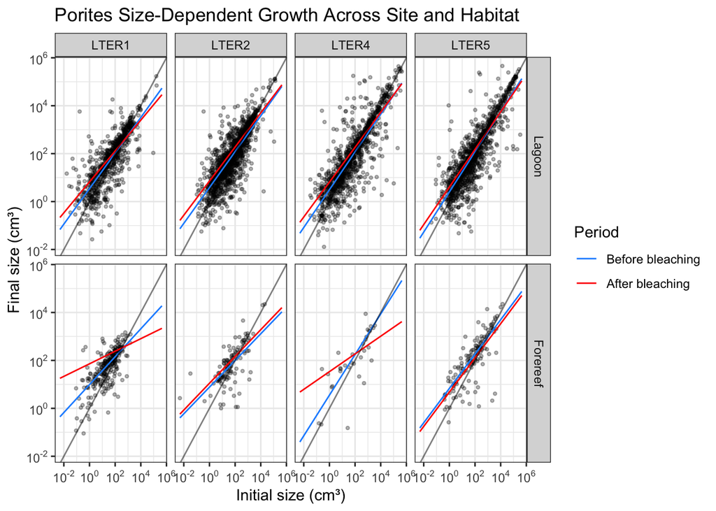

```r
ggsave(here::here("growth", "figs", "poc_site_growth_plot.png"), height = 5, width = 10)

ggplot() +
  geom_point(data = growth_por,
             aes(x = log10_size_t0, y = log10_size_t1), alpha = 0.3, size = 0.8) +
  geom_line(data = por_pred_grid_m2,
            aes(x = log10_size_t0, y = pred_log10_t1, color = period)) +
  geom_abline(slope = 1, intercept = 0, alpha = 0.5) +
  scale_color_manual(values = c("0" = "dodgerblue", "1" = "red"),
                     labels = c("0" = "Before bleaching", "1" = "After bleaching")) +
  facet_grid(habitat ~ site, labeller = labeller(habitat = c("BR" = "Lagoon", "OR" = "Forereef"))) +
  labs(x = "Initial size (cm³)",
       y = "Final size (cm³)",
       title = "Porites Size-Dependent Growth Across Site and Habitat", color = "Period") +
  scale_x_continuous(labels = scales::label_math(10^.x)) +
  scale_y_continuous(labels = scales::label_math(10^.x)) +
  theme_bw()
```

```r
ggsave(here::here("growth", "figs", "por_site_growth_plot.png"), height = 5, width = 10)
```

## Model Checks

### *Acropora* residuals

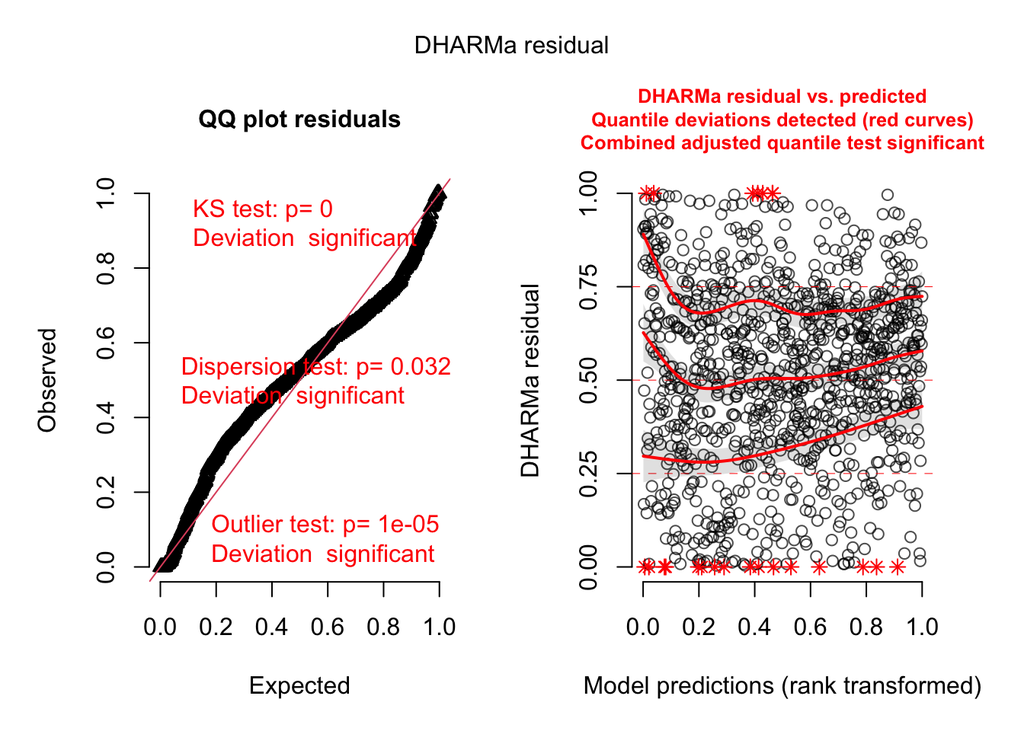

```r
acr_growth_mod2_output <- simulateResiduals(fittedModel = m2_acr, plot = FALSE)
plot(acr_growth_mod2_output)
```

### *Pocillopora* residuals

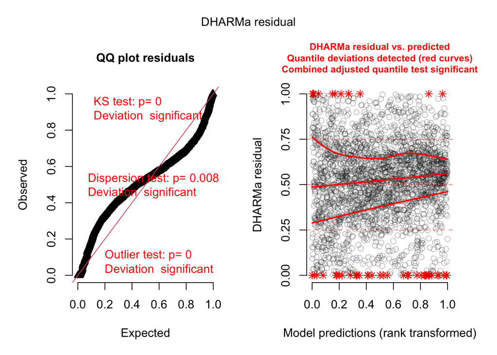

```r
poc_growth_mod2_output <- simulateResiduals(fittedModel = m2_poc, plot = FALSE)
plot(poc_growth_mod2_output)
```

### *Porites* residuals

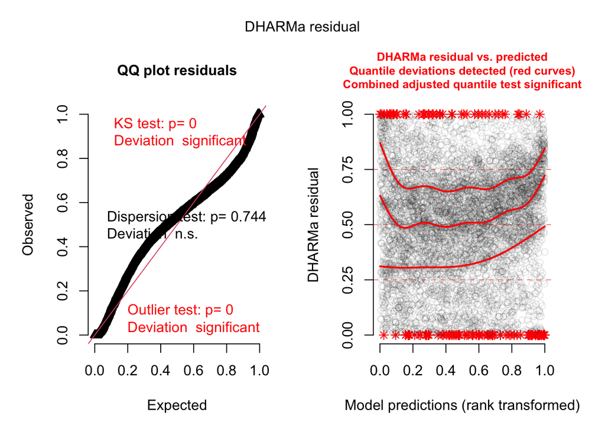

```r
por_growth_mod2_output <- simulateResiduals(fittedModel = m2_por, plot = FALSE)
plot(por_growth_mod2_output)
```